# simulation_results on simulated Spipoll

2024-07-25

## Results

### Simulation 0

Simulation la plus simple

- 3 covariables ont un effet positif
- 3 covariables ont un effet négatif
- 3 covariables sont sans effet
- L’algorithme est entrainé avec toutes les covariables

```
## [1] "AUC sessions-insectes sans covariables : 0.859"
```

```
## [1] "AUC sessions-insectes avec covariables : 0.86"
```

```
## [1] "AUC plantes-insectes sans covariables : 0.639"
```

```
## [1] "AUC plantes-insectes avec covariables : 0.643"
```

|  | Shapley | GRAD | GRADxInput | IG | GRAD_LM | IG1_LM |
| --- | --- | --- | --- | --- | --- | --- |
| + | 0.90 | 0.92 | 0.92 | 0.90 | 0.92 | 0.90 |
| - | 0.10 | 0.91 | 0.08 | 0.11 | 0.08 | 0.89 |
| AUC | 0.91 | 0.34 | 0.91 | 0.91 | 0.91 | 0.33 |

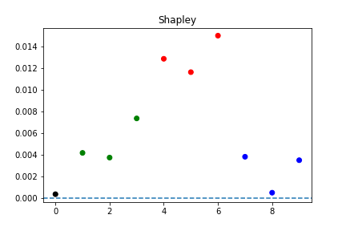

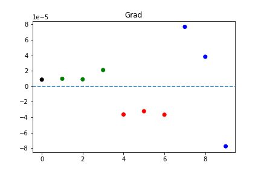

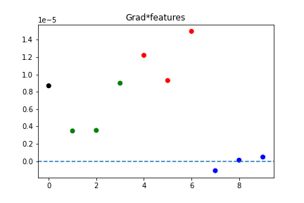

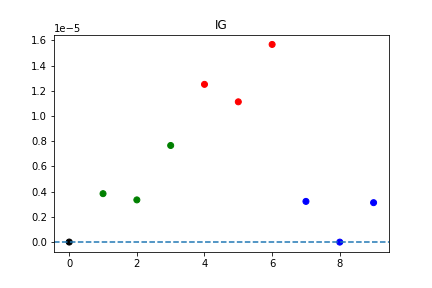

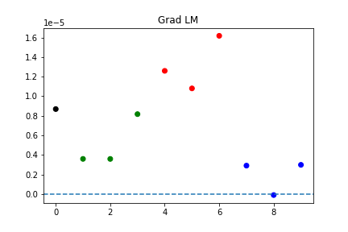

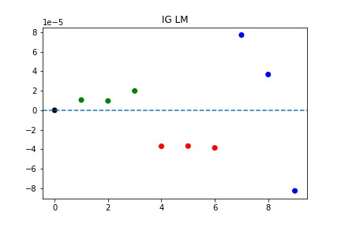

### Simulation 1

- 3 covariables ont un effet positif
- 3 covariables ont un effet négatif
- 3 covariables sont sans effet

```
## [1] "AUC sessions-insectes sans covariables : 0.863"
```

```
## [1] "AUC sessions-insectes avec covariables : 0.861"
```

```
## [1] "AUC plantes-insectes sans covariables : 0.65"
```

```
## [1] "AUC plantes-insectes avec covariables : 0.647"
```

|  | Shapley | GRAD | GRADxInput | IG | GRAD_LM | IG1_LM |
| --- | --- | --- | --- | --- | --- | --- |
| + | 0.97 | 0.92 | 0.92 | 0.95 | 0.92 | 0.92 |
| - | 0.03 | 0.98 | 0.02 | 0.02 | 0.02 | 0.97 |
| AUC | 0.91 | 0.29 | 0.89 | 0.90 | 0.91 | 0.28 |

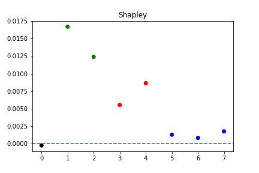

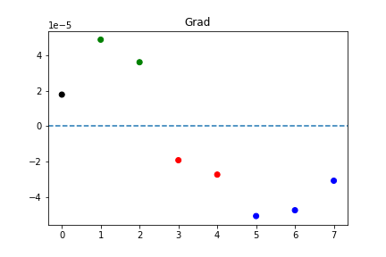

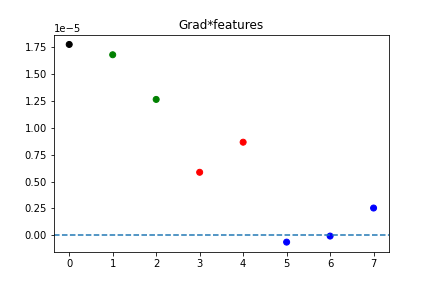

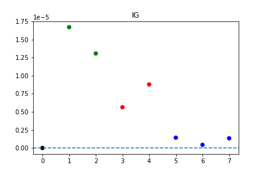

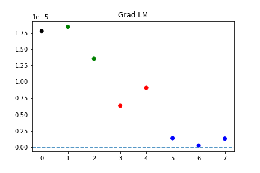

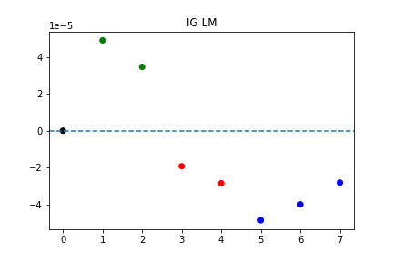

### Simulation 2

- 3 covariables ont un effet positif
- 3 covariables ont un effet négatif
- 50 covariables sont sans effet
- L’algorithme est entrainé avec toutes les covariables

```
## [1] "AUC sessions-insectes sans covariables : 0.861"
```

```
## [1] "AUC sessions-insectes avec covariables : 0.812"
```

```
## [1] "AUC plantes-insectes sans covariables : 0.636"
```

```
## [1] "AUC plantes-insectes avec covariables : 0.661"
```

|  | Shapley | GRAD | GRADxInput | IG | GRAD_LM | IG1_LM |
| --- | --- | --- | --- | --- | --- | --- |
| + | 0.70 | 0.73 | 0.73 | 0.70 | 0.73 | 0.70 |
| - | 0.34 | 0.67 | 0.33 | 0.36 | 0.33 | 0.64 |
| AUC | 0.80 | 0.15 | 0.80 | 0.79 | 0.83 | 0.15 |

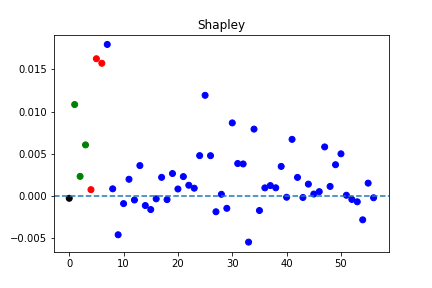

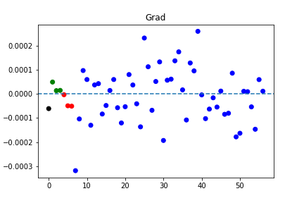

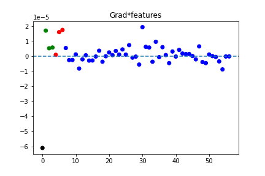

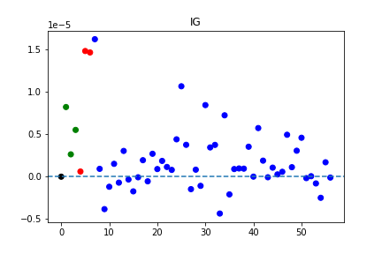

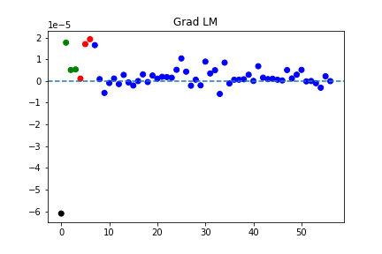

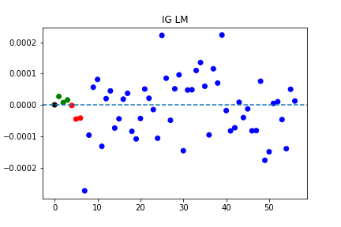

### Simulation 3

- 3 covariables ont un effet positif
- 3 covariables ont un effet négatif
- 50 covariables sont sans effet
- L’algorithme est entrainé avec
- 2 covariables ayant un effet positif
- 2 covariables ayant un effet négatif
- 50 covariables sans effet

```
## [1] "AUC sessions-insectes sans covariables : 0.86"
```

```
## [1] "AUC sessions-insectes avec covariables : 0.85"
```

```
## [1] "AUC plantes-insectes sans covariables : 0.651"
```

```
## [1] "AUC plantes-insectes avec covariables : 0.654"
```

|  | Shapley | GRAD | GRADxInput | IG | GRAD_LM | IG1_LM |
| --- | --- | --- | --- | --- | --- | --- |
| + | 0.92 | 0.93 | 0.93 | 0.92 | 0.93 | 0.92 |
| - | 0.00 | 1.00 | 0.00 | 0.00 | 0.00 | 1.00 |
| AUC | 0.96 | 0.37 | 0.96 | 0.96 | 0.96 | 0.37 |

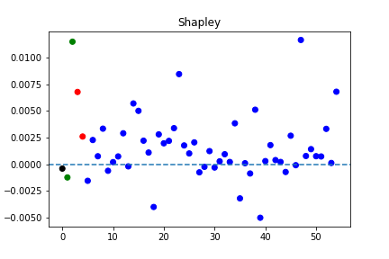

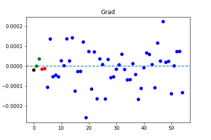

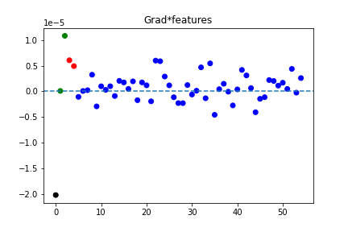

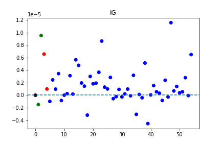

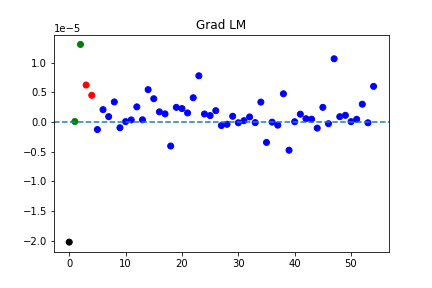

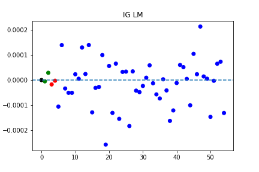

### Simulation 4

- 1 covariable a un effet qui dépend d’un groupe
- 1 covariable a un effet négatif
- 1 covariable sans effet

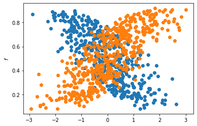

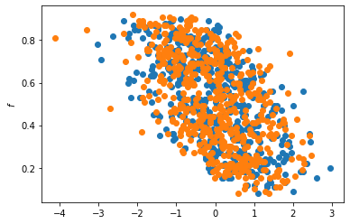

```
## [1] "AUC sessions-insectes sans covariables : 0.806"
```

```
## [1] "AUC sessions-insectes avec covariables : 0.812"
```

```
## [1] "AUC plantes-insectes sans covariables : 0.716"
```

```
## [1] "AUC plantes-insectes avec covariables : 0.723"
```

|  | Shapley | GRAD | GRADxInput | IG | GRAD_LM | IG1_LM |
| --- | --- | --- | --- | --- | --- | --- |
| + | 0.53 | 0.60 | 0.60 | 0.60 | 0.60 | 0.60 |
| - | 0.49 | 0.81 | 0.19 | 0.21 | 0.19 | 0.78 |
| AUC | 0.54 | 0.53 | 0.94 | 0.94 | 0.97 | 0.62 |

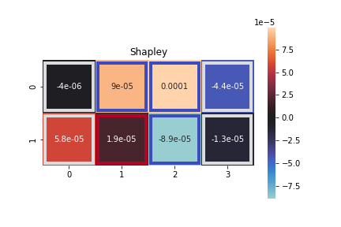

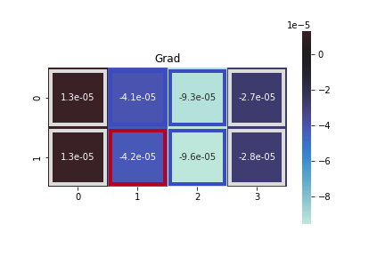

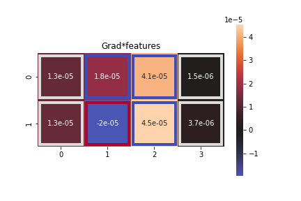

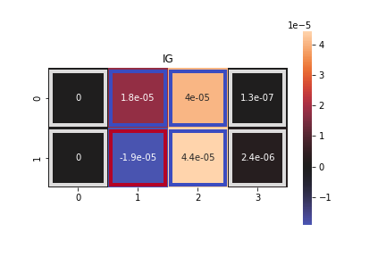

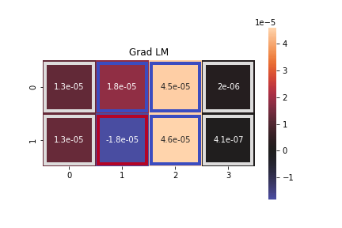

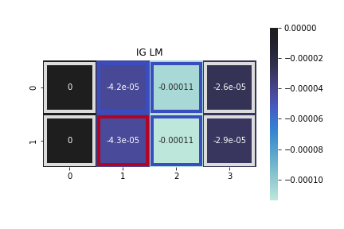